# Data Science project 2021

**Recidivism prediction** based on ProPublicas COMPAS data

**Content:**

- Intro: ProPublica's COMPAS analysis
- Data preparation
- Feature selection
- Models for Classification (general recidivism) and regression (COMPAS scores for recidivism)
  - Model iteration
  - Scoring and comparison of trained models (cross-validated and test scores)
  - Explanation of best model using `SHAP`
- Fairness discussion

# Intro: ProPublica's COMPAS analysis

- ProPublica obtained records for nearly 12,000 defendants in Broward County, Fla., who were assigned a COMPAS score in 2013-2014.
- ProPublica then determined which defendants were charged with new crimes in the subsequent two years, and made this data set publicly available.

## Correct ProPublica Two-Year Dataset

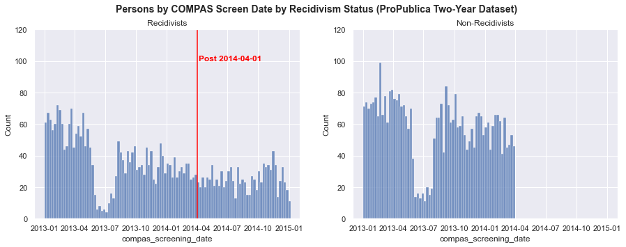

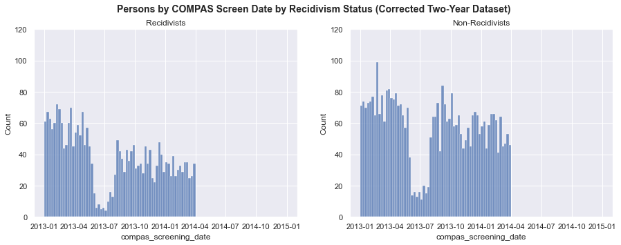

```
No. of rows in ProPublica's original dataset: 7214
No. of rows in corrected dataset: 6216
```

## Demographic breakdown

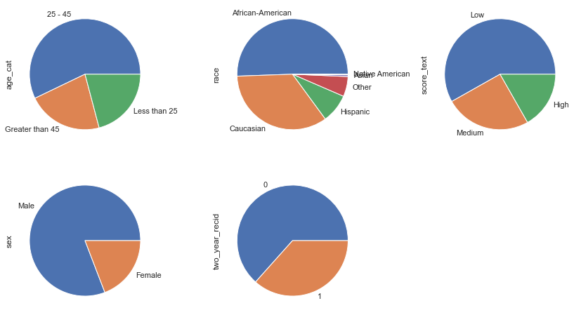

## Racial bias in COMPAS

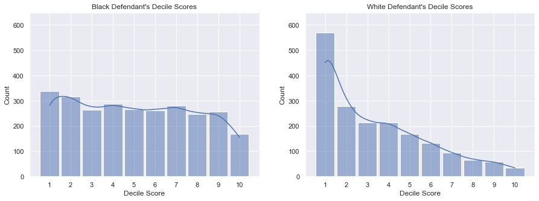

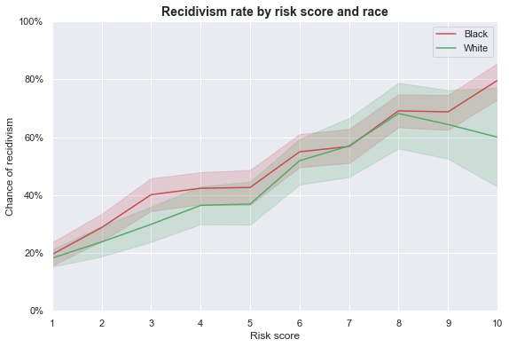